# Analyse des données

2023-01-19

## Import de packages utiles

```r
library(tables)
library(ggExtra)
library(FactoMineR)
library(factoextra)
library(CASdatasets)
library(tidyverse)
library(MASS)
library(knitr)
library(ggplot2)
library(cowplot)
library(reshape2)
library(dplyr)
library(GGally)
library(corrplot)
library(carData)
library(car)
library(questionr)
library(multcomp)
library(dplyr)
library(leaps)
library(TeachingDemos)
library(FactoMineR)
library(factoextra)
library(ROCR)
library(plotROC)
library(graphics)
```

## Documentation et import du dataset

```r
#?CASdatasets #ouvre l'aide pour comprendre le dataset
data(freMPL5)
summary(freMPL5)
```

```
##     Exposure         LicAge      RecordBeg            RecordEnd
##  Min.   :0.001   Min.   : 24   Min.   :2004-01-01   Min.   :2004-01-02
##  1st Qu.:0.170   1st Qu.:229   1st Qu.:2004-01-01   1st Qu.:2004-05-01
##  Median :0.403   Median :355   Median :2004-04-15   Median :2004-07-18
##  Mean   :0.423   Mean   :350   Mean   :2004-05-07   Mean   :2004-07-20
##  3rd Qu.:0.666   3rd Qu.:463   3rd Qu.:2004-08-11   3rd Qu.:2004-10-14
##  Max.   :1.000   Max.   :844   Max.   :2004-12-31   Max.   :2004-12-31
##                                                     NA's   :12818
##     Gender       MariStat       SocioCateg                      VehUsage
##  Female: 8856   Alone: 3461   CSP50  :12385   Private               : 8576
##  Male  :17144   Other:22539   CSP60  : 5646   Private+trip to office:12163
##                               CSP55  : 3247   Professional          : 4299
##                               CSP1   :  960   Professional run      :  962
##                               CSP66  :  672
##                               CSP42  :  655
##                               (Other): 2435
##     DrivAge        HasKmLimit       ClaimAmount       ClaimNbResp
##  Min.   :20.00   Min.   :0.00000   Min.   :-1842.0   Min.   :0.0000
##  1st Qu.:39.00   1st Qu.:0.00000   1st Qu.:    0.0   1st Qu.:0.0000
##  Median :51.00   Median :0.00000   Median :    0.0   Median :0.0000
##  Mean   :50.45   Mean   :0.07462   Mean   :  204.9   Mean   :0.2663
##  3rd Qu.:61.00   3rd Qu.:0.00000   3rd Qu.:    0.0   3rd Qu.:0.0000
##  Max.   :95.00   Max.   :1.00000   Max.   :95151.0   Max.   :4.0000
##
##  ClaimNbNonResp   ClaimNbParking    ClaimNbFireTheft  ClaimNbWindscreen
##  Min.   :0.0000   Min.   :0.00000   Min.   :0.00000   Min.   :0.000
##  1st Qu.:0.0000   1st Qu.:0.00000   1st Qu.:0.00000   1st Qu.:0.000
##  Median :0.0000   Median :0.00000   Median :0.00000   Median :0.000
##  Mean   :0.3218   Mean   :0.08265   Mean   :0.07638   Mean   :0.418
##  3rd Qu.:1.0000   3rd Qu.:0.00000   3rd Qu.:0.00000   3rd Qu.:1.000
##  Max.   :7.0000   Max.   :4.00000   Max.   :3.00000   Max.   :8.000
##
##     OutUseNb         RiskArea        BonusMalus        ClaimInd
##  Min.   :0.0000   Min.   : 1.000   Min.   : 50.00   Min.   :0.000
##  1st Qu.:0.0000   1st Qu.: 6.000   1st Qu.: 50.00   1st Qu.:0.000
##  Median :0.0000   Median : 7.000   Median : 50.00   Median :0.000
##  Mean   :0.2243   Mean   : 7.845   Mean   : 57.78   Mean   :0.093
##  3rd Qu.:0.0000   3rd Qu.:10.000   3rd Qu.: 60.00   3rd Qu.:0.000
##  Max.   :5.0000   Max.   :13.000   Max.   :185.00   Max.   :1.000
##
```

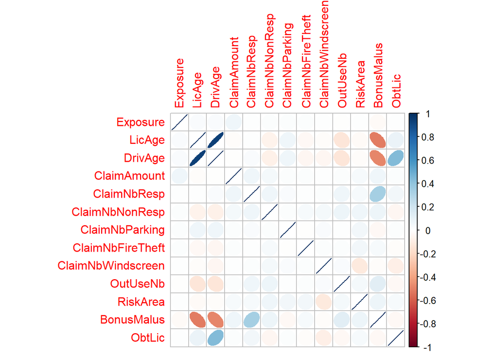

```r
#Cette nouvelle covariable sera présentée plus tard
freMPL5$ObtLic <- ceiling(freMPL5$DrivAge - freMPL5$LicAge/12)
x <- freMPL5[, c(1,2,9,11,12,13,14,15,16,17,18,19,21)]
corrplot(round(cor(x),2),method="ellipse")
```

freMPL veut dire French Motor Personal Line datasets. On utilisera le dataset 5 qui contient environ 26000 contrats de l’annee 2004.

On a ici un premier résumé des variables avec des premières corrélations uniquement pour les variables continues.

On voit des fortes corrélations en valeur absolue entre BonusMalus, DrivAge et LicAge. Cela peut facilement se comprendre car l’âge du conducteur et le temps écoulé depuis qu’il a obtenu son permis sont souvent fortement lié. On pourrait d’ailleurs éventuellement créer une variable pour connaitre l’âge du conducteur lorsqu’il a obtenu le permis.

On remarque que certaines variables sont numériques au lieu d’être considérées comme des facteurs. Nous allons donc les changer :

```r
freMPL5$HasKmLimit <- factor(freMPL5$HasKmLimit)
freMPL5$ClaimInd <- factor(freMPL5$ClaimInd)
freMPL5$RiskArea <- factor(freMPL5$RiskArea)
freMPL5$OutUseNb <- as.numeric(freMPL5$OutUseNb)
```

### Remarque sur les données

```r
summary(freMPL5$ClaimAmount[freMPL5$ClaimInd == 1]) #resumé lorsque de l'argent est demandé
```

```
##     Min.  1st Qu.   Median     Mean  3rd Qu.     Max.
##     8.84   345.71   800.95  2277.22  2089.58 95150.96
```

```r
summary(freMPL5$ClaimAmount[freMPL5$ClaimInd == 0])
```

```
##      Min.   1st Qu.    Median      Mean   3rd Qu.      Max.
## -1842.014     0.000     0.000    -7.584     0.000     0.000
```

On remarque donc l’apparition de quelques données étranges. En effet, on a l’apparition de variables de coût négatives. Ceci est du à une régularisation. ne pouvant pas traiter cela, nous supprimerons les lignes correspondantes qui sont au nombre de 278.

```r
sum(ifelse(freMPL5$ClaimAmount[freMPL5$ClaimInd == 0]<0,1,0)) #=278
```

```
## [1] 278
```

Nous supprimons alors les lignes en questions :

```r
freMPL5 <- subset(freMPL5, freMPL5$ClaimAmount >= 0)
```

### Notes

**Revoir la partie 2.4.2 de Wuthrish pour bien analyser proprement les variables qui ont un impact linéaire de celles qui n’ont pas un tel impact. Cela justifiera alors de rendre ces variables catégorielles ou non. Cela peut être fait avec les log-fréquences marginales des covariables continues.**

Pour le document LateX, on pourra présenter les données et surtout, le cadre du GLM comme le fait Wuthrish page 47 (Partie 2.4.5) du polycopié Wuthrish et Buser.

### Coefficient de bonus-malus

Pour le coefficient de bonus-malus, il commence à 1 et peut descendre jusqu’à 0.5 si le conducteur n’a pas d’accidents responsables ou semi-responsables. A l’inverse, en cas d’accidents responsables, le coefficient augmente et peut atteindre jusqu’à 3.5. Dans le jeu de données, toutes les valeurs sont multipliées par 100 ce qui ne posera aucun problème dans le cas de nos modèles. Cependant, si on veut voir l’impact linéaire du coefficient de bonus-malus, il pourrait être intéressant de revoir son échelle en retranchant 100 par exemple à la variable. C’est pour cela qu’il y a une corrélation assez importante entre BonusMalus et ClaimNbResp.

Dans notre jeu de données, la valeur maximale est 1.85. Nous n’avons donc aucune information sur des éventuels assurés possédant un malus supérieur. Cela pourra donc être compliqué de prédire les primes d’assurances pour ce genre d’assurés. De manière générale, ici on a princialement des bons conducteurs puisque la médianne vaut 0.5 et le 3eme quartile 0.6 et 95% des assurés sont en dessous de 0.90.

```r
summary(freMPL5$BonusMalus)
```

```
##    Min. 1st Qu.  Median    Mean 3rd Qu.    Max.
##   50.00   50.00   50.00   57.75   60.00  185.00
```

```r
quantile(freMPL5$BonusMalus, seq(0,1,0.05))
```

```
##   0%   5%  10%  15%  20%  25%  30%  35%  40%  45%  50%  55%  60%  65%  70%  75%
##   50   50   50   50   50   50   50   50   50   50   50   50   50   51   55   60
##  80%  85%  90%  95% 100%
##   65   72   80   90  185
```

##### Etude par rapport à la sinistralité

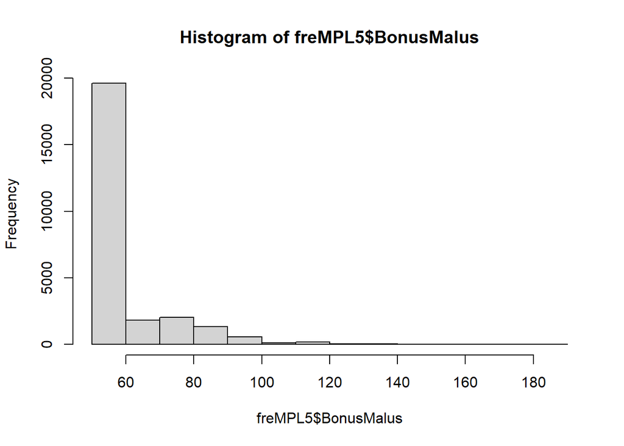

```r
hist(freMPL5$BonusMalus)
```

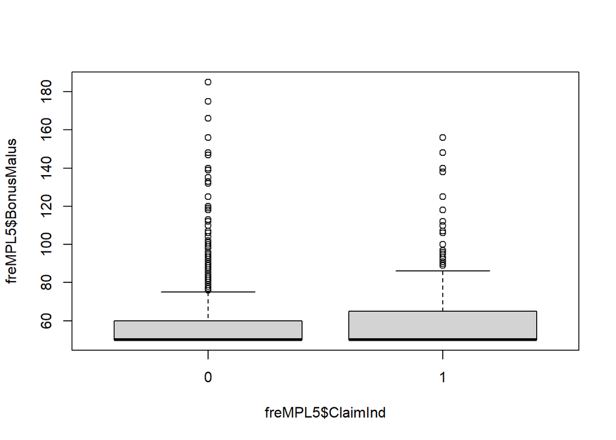

```r
boxplot(freMPL5$BonusMalus ~ freMPL5$ClaimInd)
```

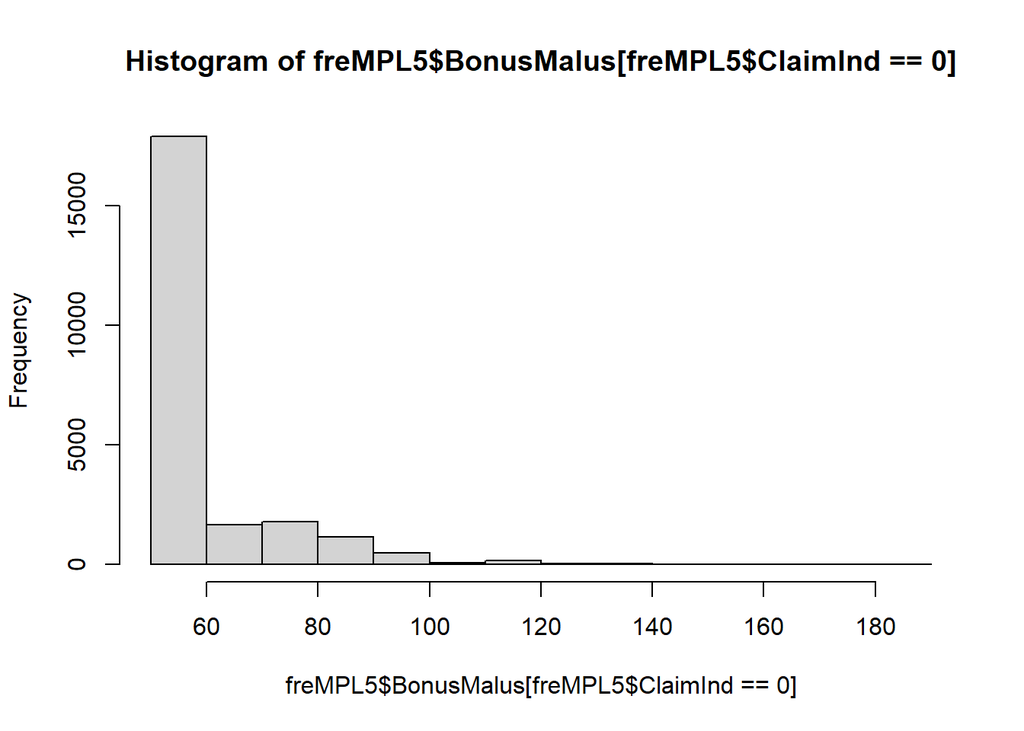

```r
hist(freMPL5$BonusMalus[freMPL5$ClaimInd == 0])
```

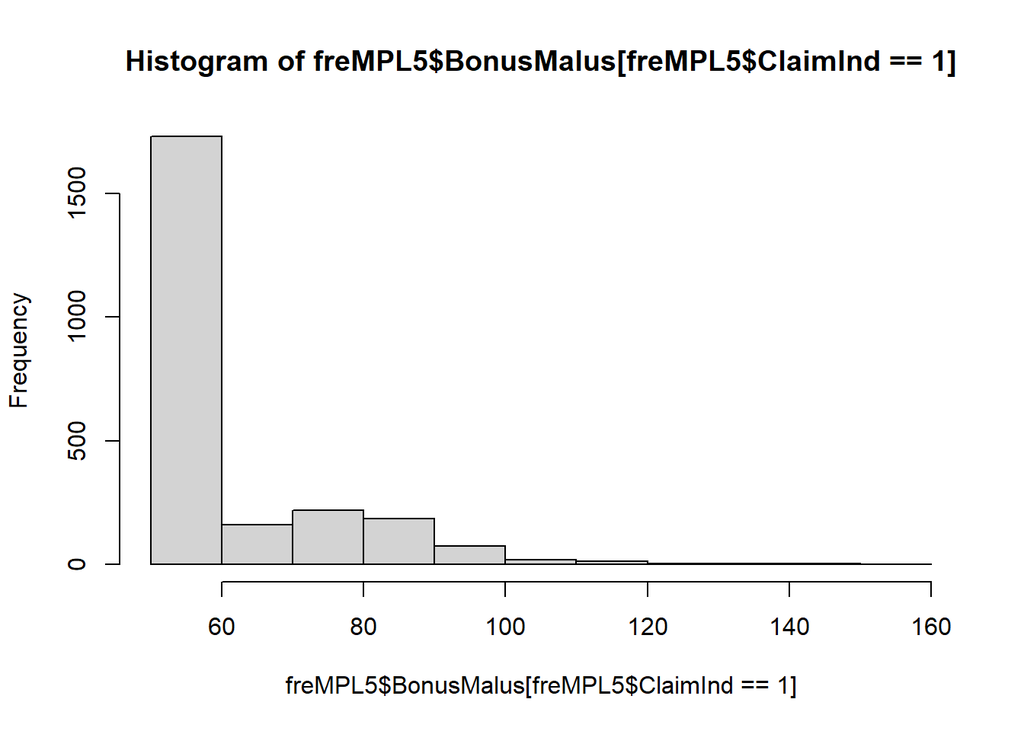

```r
hist(freMPL5$BonusMalus[freMPL5$ClaimInd == 1])
```

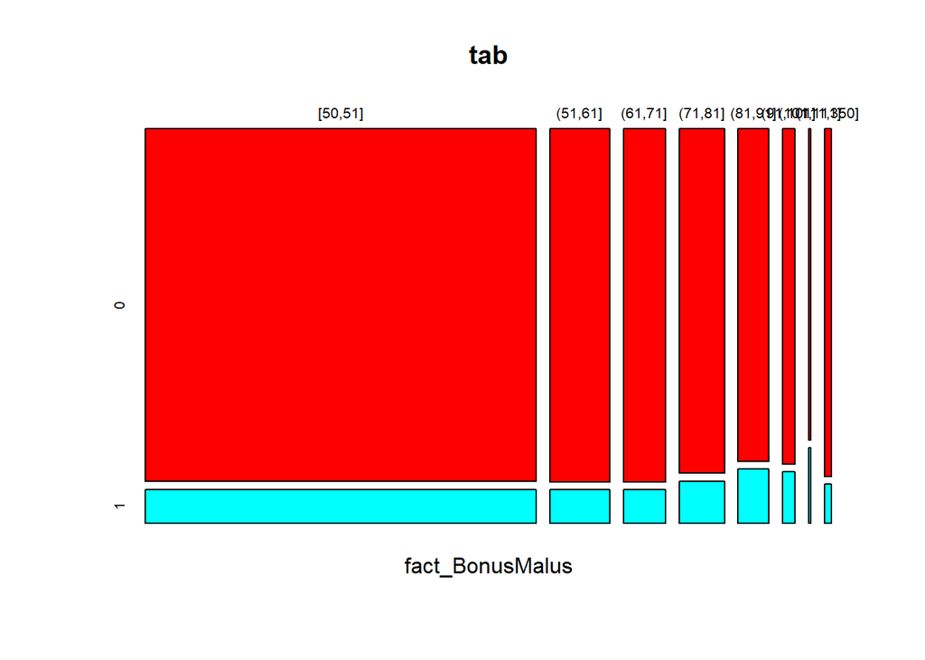

```r
fact_BonusMalus <- cut(freMPL5$BonusMalus, c(50,seq(51,120,10),350), include.lowest = TRUE)
tab <- table(fact_BonusMalus, freMPL5$ClaimInd)
cols <- rainbow(nlevels(freMPL5$ClaimInd))
plot(tab,col = cols)
```

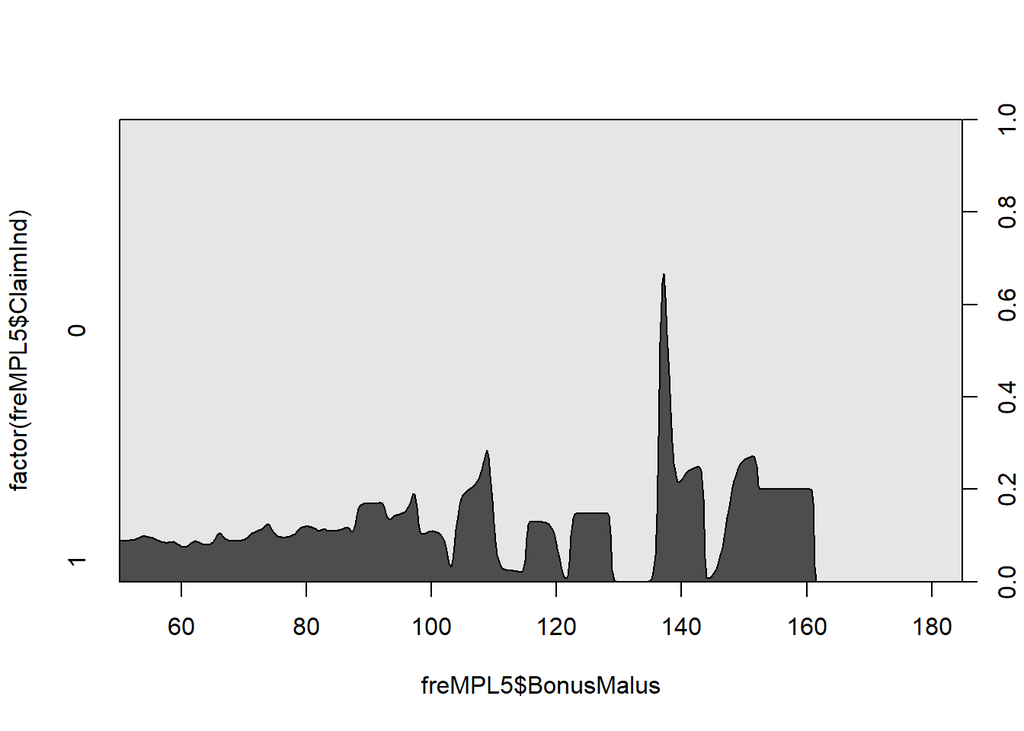

```r
cdplot(x = freMPL5$BonusMalus, y = factor(freMPL5$ClaimInd))
```

##### Etude par rapport au coût

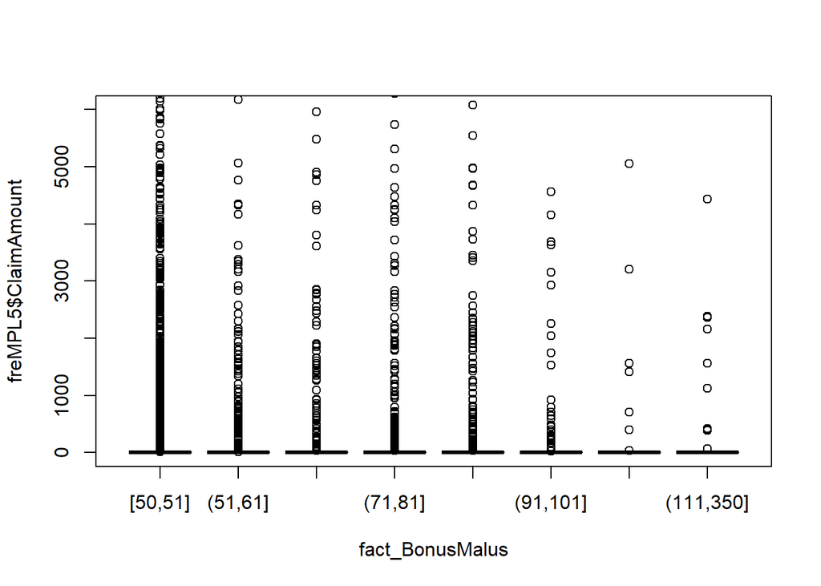

```r
boxplot(freMPL5$ClaimAmount ~ fact_BonusMalus, ylim=c(0,6000))
```

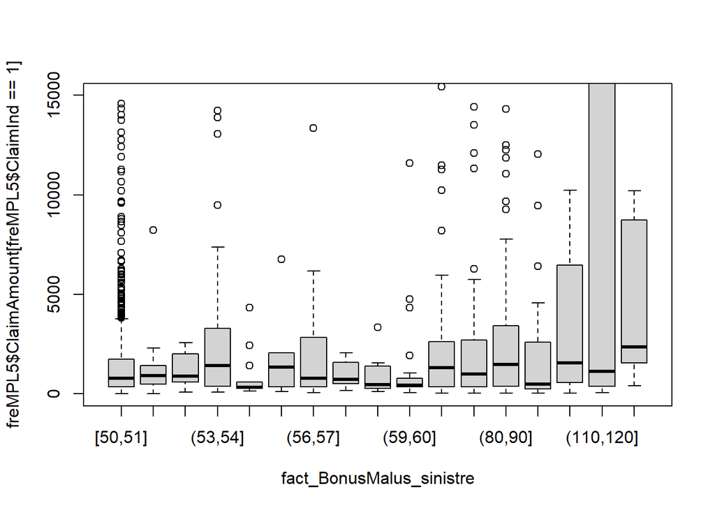

```r
fact_BonusMalus_sinistre <- cut(freMPL5$BonusMalus[freMPL5$ClaimInd == 1], c(seq(50,59,1),seq(60,120,10),350), include.lowest = TRUE)
boxplot(freMPL5$ClaimAmount[freMPL5$ClaimInd == 1] ~ fact_BonusMalus_sinistre, ylim=c(0,15000))
```

Le premier graphique n’étant pas interprétable, nous avons créé le deuxieme qui semble nous donner une certaine tendance : plus le coefficient de malus est élevé et plus le coût moyen augmente.

# Covariables liées à l’âge

### Etude de la variable d’âge (DrivAge)

```r
summary(freMPL5$DrivAge)
```

```
##    Min. 1st Qu.  Median    Mean 3rd Qu.    Max.
##    20.0    39.0    51.0    50.5    61.0    95.0
```

```r
cor.test(freMPL5$LicAge, freMPL5$DrivAge)
```

```
##
##  Pearson's product-moment correlation
##
## data:  freMPL5$LicAge and freMPL5$DrivAge
## t = 414.55, df = 25720, p-value < 2.2e-16
## alternative hypothesis: true correlation is not equal to 0
## 95 percent confidence interval:
##  0.9310313 0.9342136
## sample estimates:
##       cor
## 0.9326406
```

```r
cor.test(freMPL5$ClaimAmount, freMPL5$DrivAge)
```

```
##
##  Pearson's product-moment correlation
##
## data:  freMPL5$ClaimAmount and freMPL5$DrivAge
## t = -2.1738, df = 25720, p-value = 0.02973
## alternative hypothesis: true correlation is not equal to 0
## 95 percent confidence interval:
##  -0.025769546 -0.001332446
## sample estimates:
##         cor
## -0.01355302
```

```r
cor.test(as.numeric(freMPL5$ClaimInd), freMPL5$DrivAge)
```

```
##
##  Pearson's product-moment correlation
##
## data:  as.numeric(freMPL5$ClaimInd) and freMPL5$DrivAge
## t = -5.6553, df = 25720, p-value = 1.573e-08
## alternative hypothesis: true correlation is not equal to 0
## 95 percent confidence interval:
##  -0.04744125 -0.02303001
## sample estimates:
##         cor
## -0.03524089
```

On voit que les variables LicAge et DrivAge sont fortement corrélées par le test de Pearson.

De plus, on a des corrélations avec ClaimAmount et Claim Ind.

##### Etude par rapport à la sinistralité

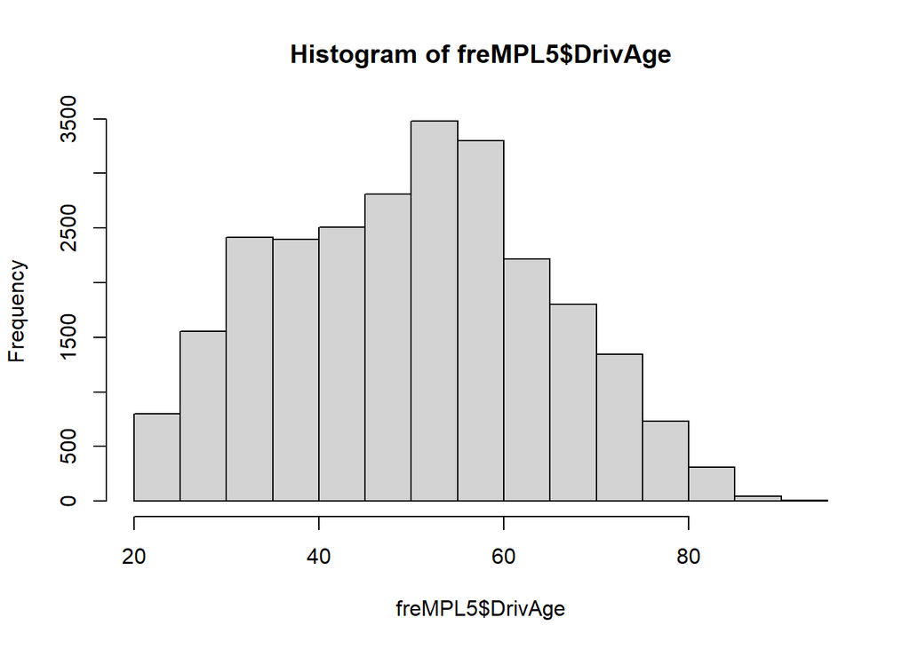

```r
hist(freMPL5$DrivAge)
```

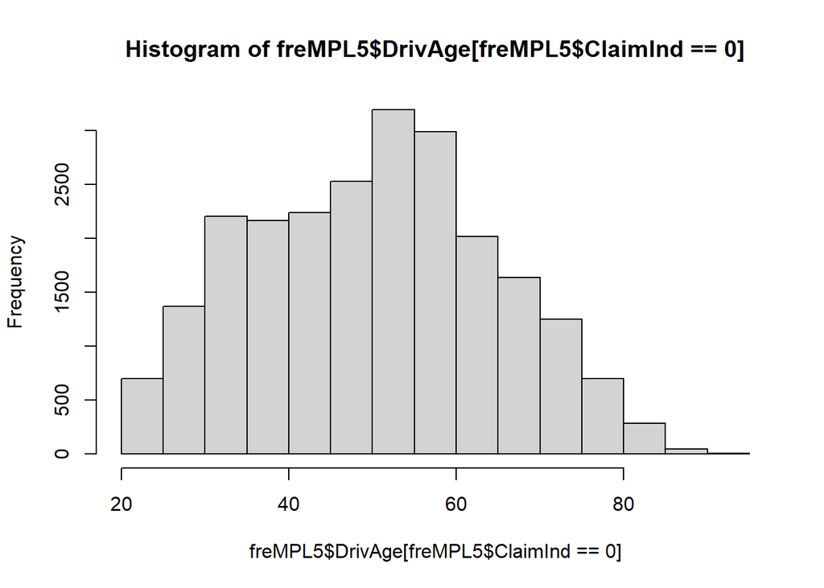

```r
hist(freMPL5$DrivAge[freMPL5$ClaimInd == 0])
```

```r
summary(freMPL5$DrivAge[freMPL5$ClaimInd == 0])
```

```
##    Min. 1st Qu.  Median    Mean 3rd Qu.    Max.
##   20.00   39.00   51.00   50.66   61.00   95.00
```

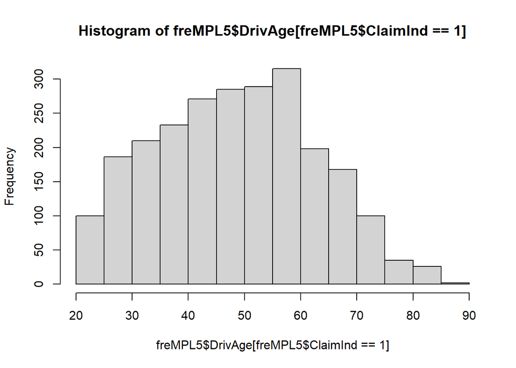

```r
hist(freMPL5$DrivAge[freMPL5$ClaimInd == 1])
```

```r
summary(freMPL5$DrivAge[freMPL5$ClaimInd == 1])
```

```
##    Min. 1st Qu.  Median    Mean 3rd Qu.    Max.
##   20.00   38.00   49.00   48.92   59.00   88.00
```

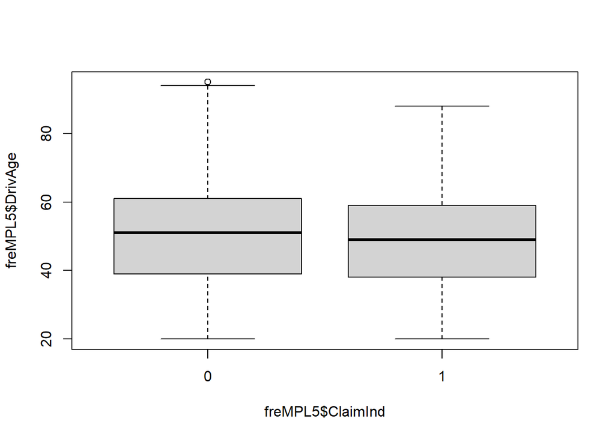

```r
boxplot(freMPL5$DrivAge ~ freMPL5$ClaimInd)
```

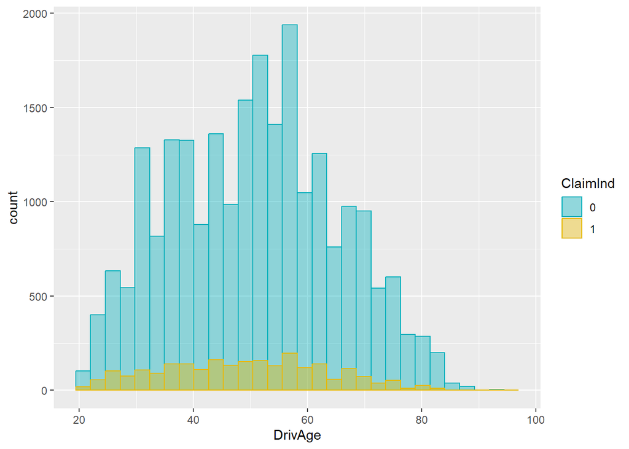

```r
ggplot(freMPL5, aes(x = DrivAge)) +
  geom_histogram(aes(color = ClaimInd, fill = ClaimInd),
                position = "identity", bins = 30, alpha = 0.4) +
  scale_color_manual(values = c("#00AFBB", "#E7B800")) +
  scale_fill_manual(values = c("#00AFBB", "#E7B800"))
```

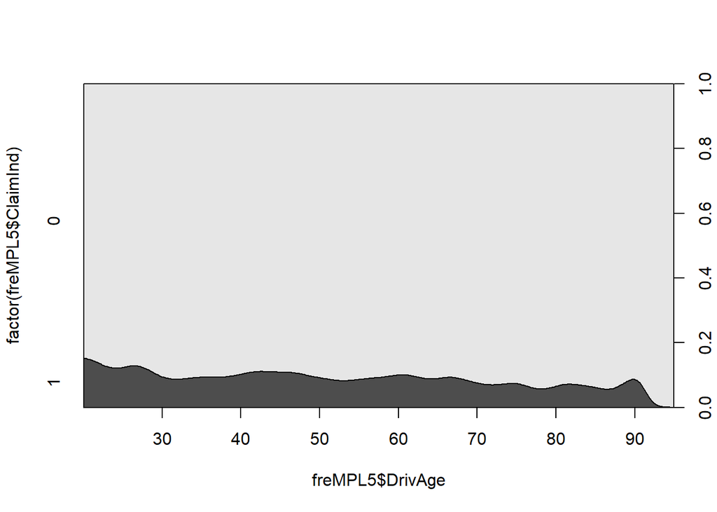

```r
cdplot(x = freMPL5$DrivAge, y = factor(freMPL5$ClaimInd))
```

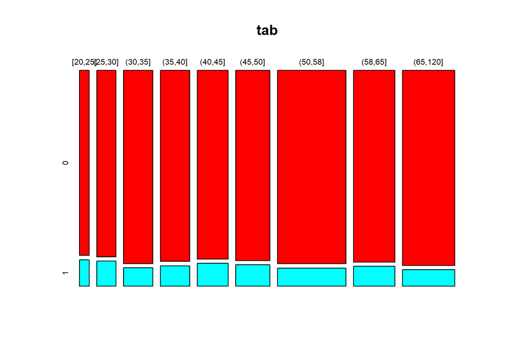

```r
freMPL5$DrivAge_fact <- cut(freMPL5$DrivAge, c(20,25,30,35,40,45,50,58,65,120), include.lowest = TRUE)
tab <- table(freMPL5$DrivAge_fact, freMPL5$ClaimInd)
cols <- rainbow(nlevels(freMPL5$ClaimInd))
plot(tab,col = cols)
```

L’âge du conducteur semble donc avoir un impact dans le risque d’avoir un sinistre (plus on est jeune, et plus on risque de coûter de l’argent à l’assurance). En effet, la proportion de 35-50 ans est très forte mais il n’y a pas beaucoup de sinistres comparé aux 20-30 ans.

##### Etude par rapport au coût

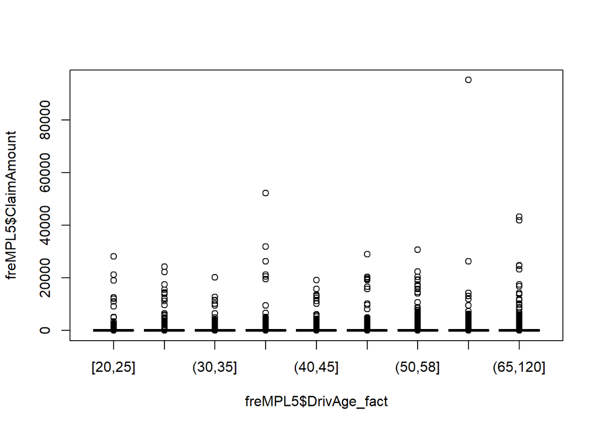

```r
plot(freMPL5$ClaimAmount ~ freMPL5$DrivAge_fact)
boxplot(freMPL5$ClaimAmount ~ freMPL5$DrivAge_fact)
```

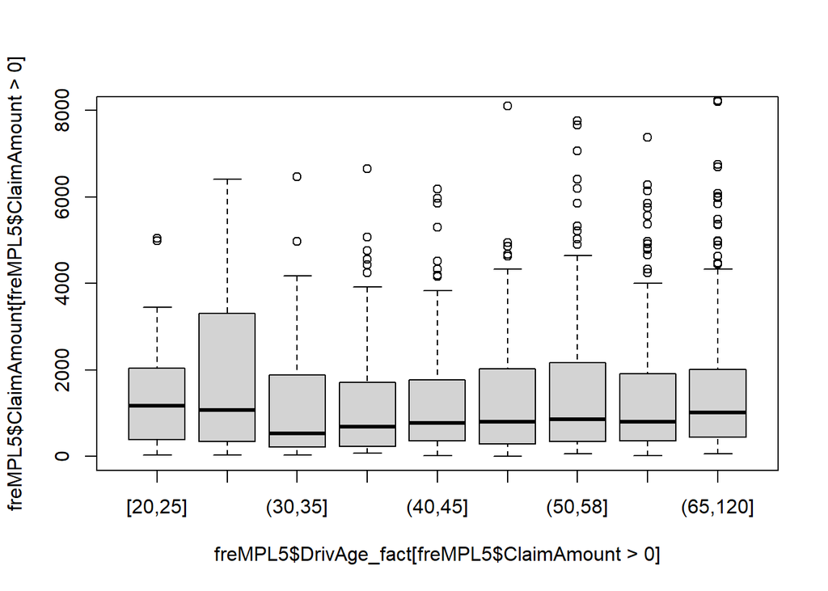

```r
boxplot(freMPL5$ClaimAmount[freMPL5$ClaimAmount>0] ~ freMPL5$DrivAge_fact[freMPL5$ClaimAmount>0], ylim=c(0,8000))
```

On observe donc un risque accru pour les jeunes conducteurs mais on remarque aussi que le risque augmente de nouveau après 50 ans (cela pourrait correspondre au moment où les enfants sont en âge de conduire sur le véhicule des parents).

#### Etude d’un lien avec les Catégories Socio-Professionnelles

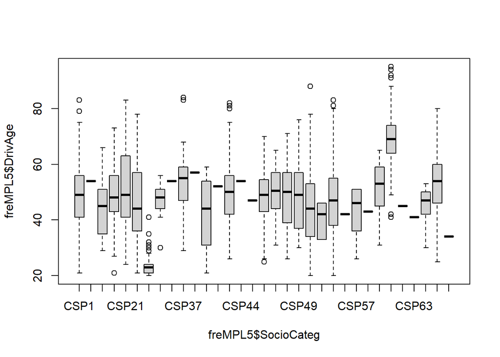

```r
plot(freMPL5$DrivAge ~ freMPL5$SocioCateg)
```

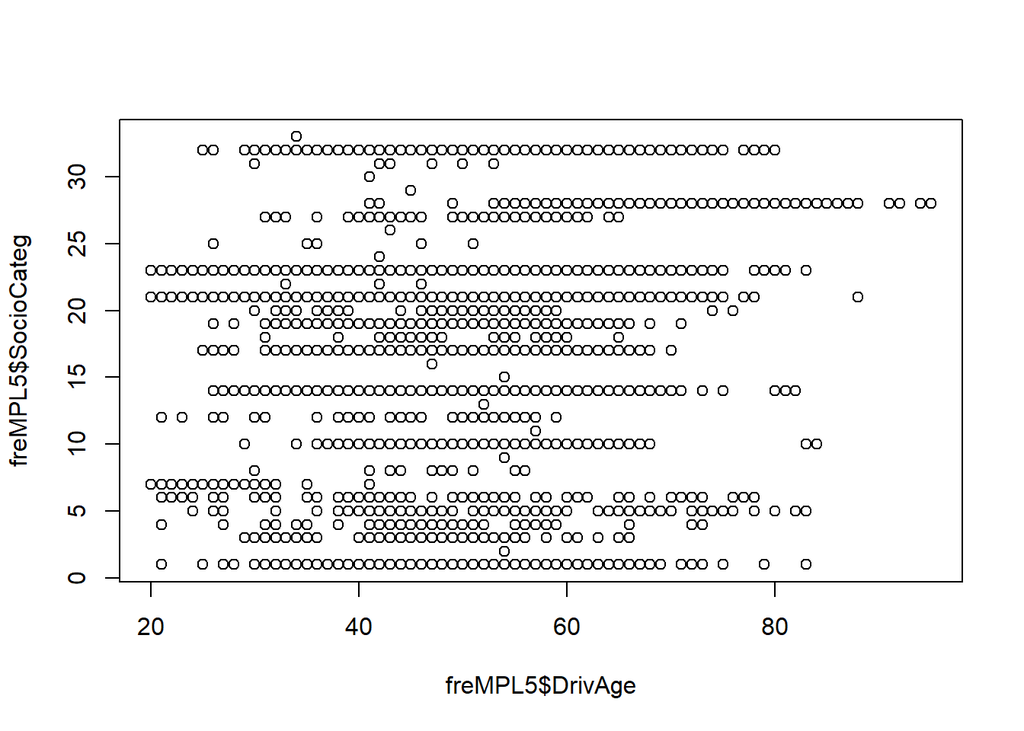

```r
plot(freMPL5$DrivAge, freMPL5$SocioCateg)
```

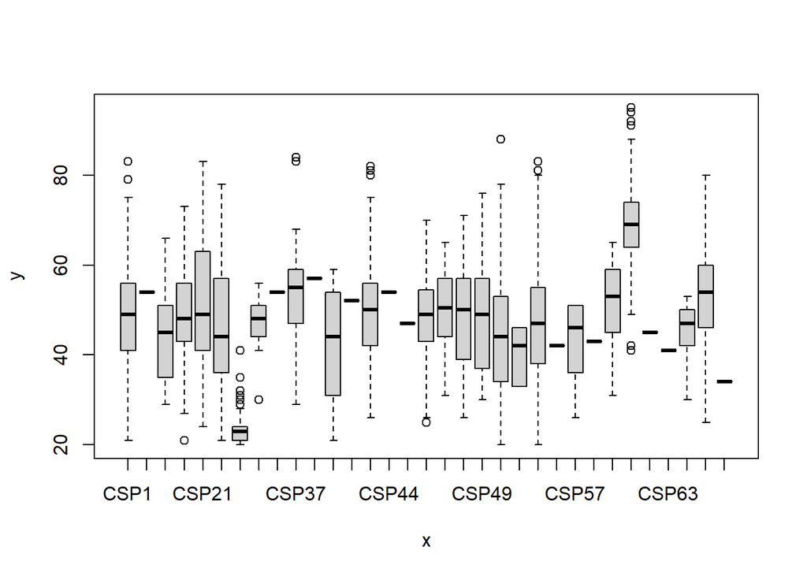

```r
plot(freMPL5$SocioCateg, freMPL5$DrivAge)
```

```r
summary(c(freMPL5$DrivAge, freMPL5$SocioCateg))
```

```
##    Min. 1st Qu.  Median    Mean 3rd Qu.    Max.
##    1.00   21.00   28.00   36.01   51.00   95.00
```

### Etude de la variable d’ancienneté du permis (LicAge)

Cette variable est exprimée en mois. Nous rappelons qu’elle est très corrélée avec DrivAge et Bonus-Malus.

```r
summary(freMPL5$LicAge)
```

```
##    Min. 1st Qu.  Median    Mean 3rd Qu.    Max.
##    24.0   230.0   356.0   350.5   464.0   844.0
```

```r
cor.test(freMPL5$ClaimAmount, freMPL5$LicAge)
```

```
##
##  Pearson's product-moment correlation
##
## data:  freMPL5$ClaimAmount and freMPL5$LicAge
## t = -3.0887, df = 25720, p-value = 0.002012
## alternative hypothesis: true correlation is not equal to 0
## 95 percent confidence interval:
##  -0.031469102 -0.007036575
## sample estimates:
##         cor
## -0.01925571
```

```r
cor.test(as.numeric(freMPL5$ClaimInd), freMPL5$LicAge)
```

```
##
##  Pearson's product-moment correlation
##
## data:  as.numeric(freMPL5$ClaimInd) and freMPL5$LicAge
## t = -5.6089, df = 25720, p-value = 2.057e-08
## alternative hypothesis: true correlation is not equal to 0
## 95 percent confidence interval:
##  -0.04715322 -0.02274149
## sample estimates:
##         cor
## -0.03495257
```

On conclut également à une corrélation avec les variables à expliquer.

##### Etude par rapport à la sinistralité

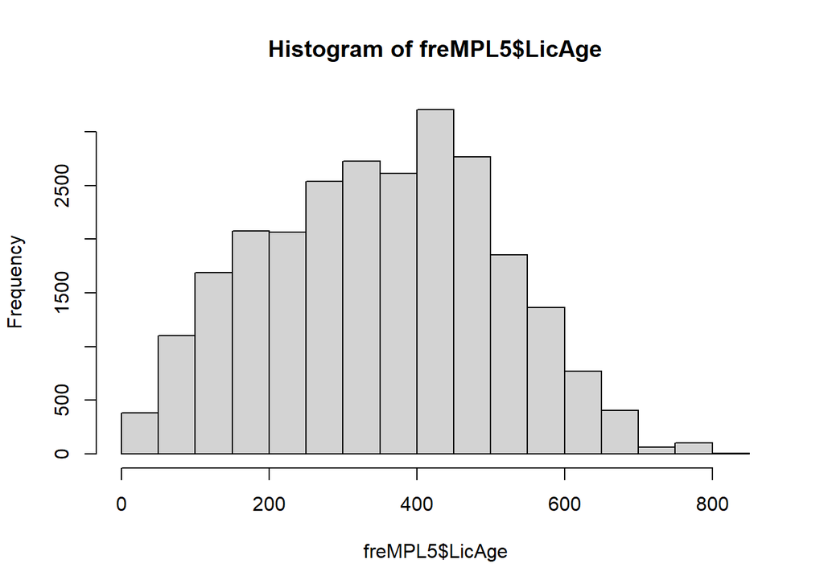

```r
hist(freMPL5$LicAge)
```

```r
summary(freMPL5$LicAge[freMPL5$ClaimInd == 0])
```

```
##    Min. 1st Qu.  Median    Mean 3rd Qu.    Max.
##    24.0   231.0   357.5   352.3   465.0   821.0
```

```r
summary(freMPL5$LicAge[freMPL5$ClaimInd == 1])
```

```
##    Min. 1st Qu.  Median    Mean 3rd Qu.    Max.
##    24.0   216.0   334.0   333.5   451.0   844.0
```

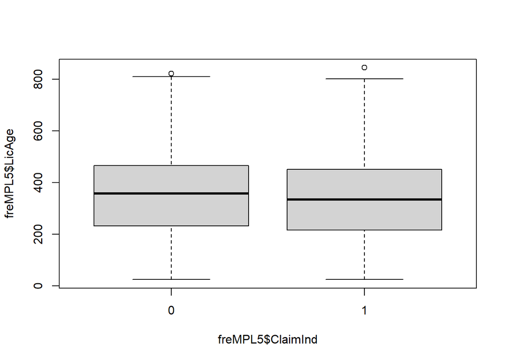

```r
boxplot(freMPL5$LicAge ~ freMPL5$ClaimInd)
```

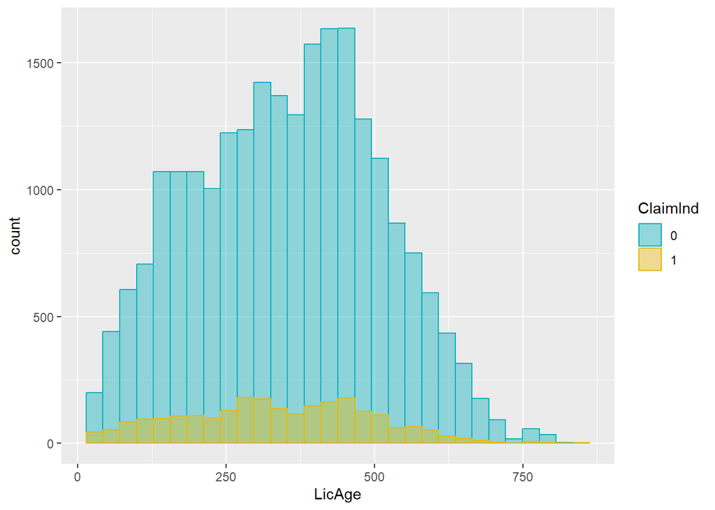

```r
ggplot(freMPL5, aes(x = LicAge)) +
  geom_histogram(aes(color = ClaimInd, fill = ClaimInd),
                position = "identity", bins = 30, alpha = 0.4) +
  scale_color_manual(values = c("#00AFBB", "#E7B800")) +
  scale_fill_manual(values = c("#00AFBB", "#E7B800"))
```

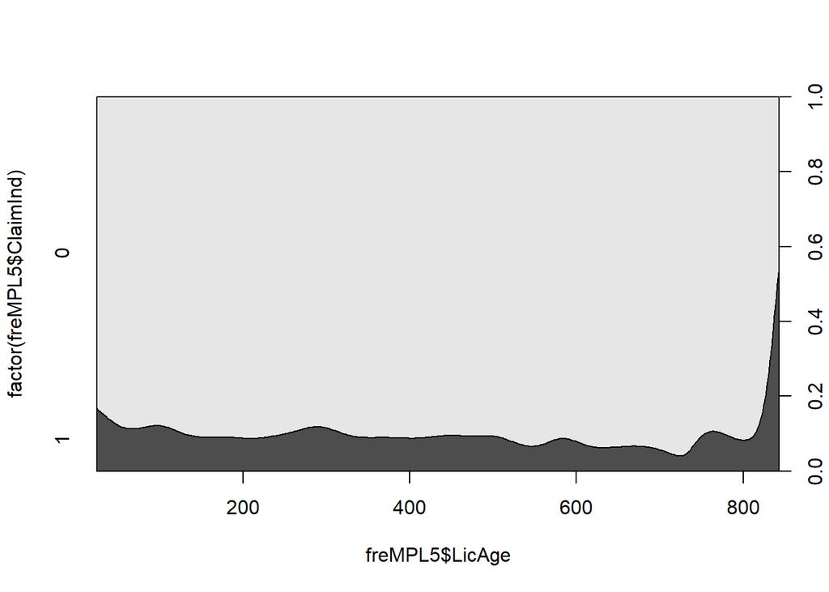

```r
cdplot(x = freMPL5$LicAge, y = factor(freMPL5$ClaimInd))
```

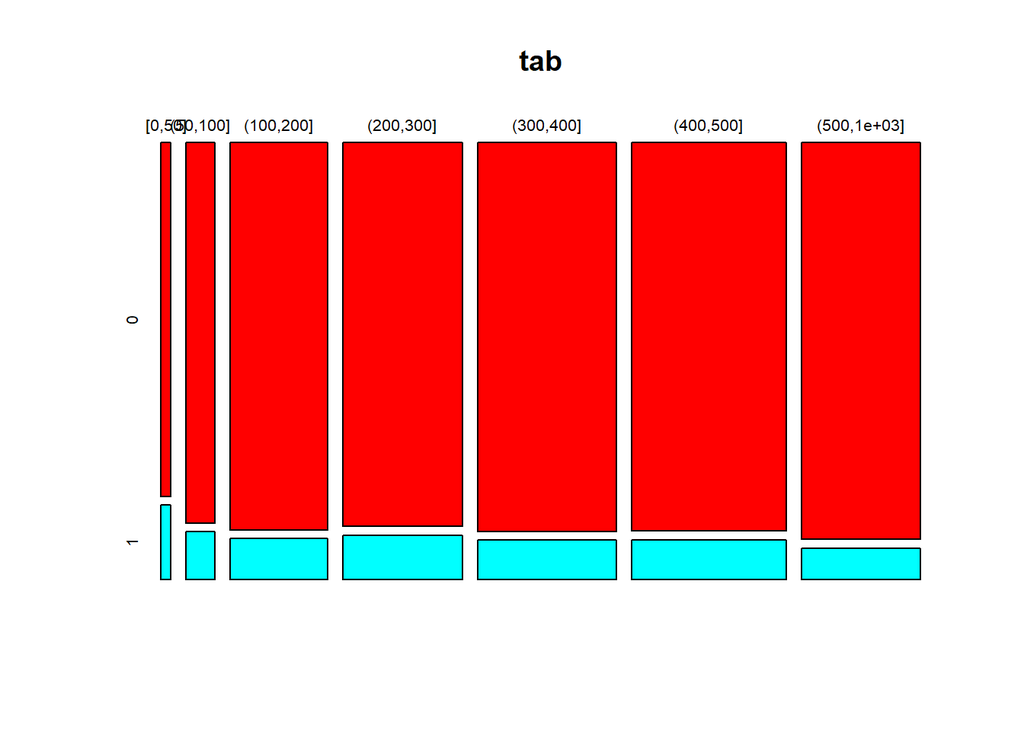

```r
freMPL5$LicAge <- cut(freMPL5$LicAge, c(0,50,100,200,300,400,500,1000), include.lowest = TRUE)
tab <- table(freMPL5$LicAge, freMPL5$ClaimInd)
cols <- rainbow(nlevels(freMPL5$ClaimInd))
plot(tab,col = cols)
```

On retrouve à peu près les mêmes résultats ici que pour DrivAge. L’interprétation est la même.

##### Etude par rapport au coût

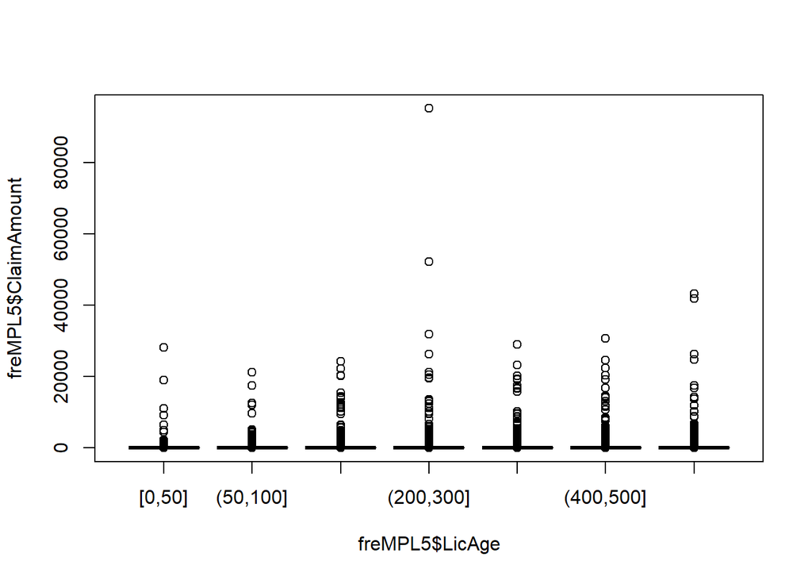

```r
plot(freMPL5$ClaimAmount ~ freMPL5$LicAge)
#freMPL5$LicAge <- cut(freMPL5$LicAge, quantile(freMPL5$LicAge, probs = seq(0,1,1/6)), include.lowest = TRUE)
#variable déjà transformée en facteur plus haut
boxplot(freMPL5$ClaimAmount ~ freMPL5$LicAge)
```

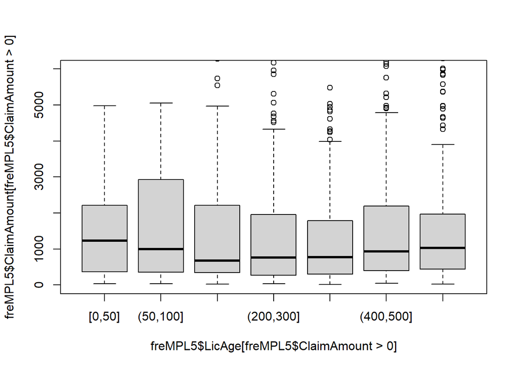

```r
boxplot(freMPL5$ClaimAmount[freMPL5$ClaimAmount>0] ~ freMPL5$LicAge[freMPL5$ClaimAmount>0], ylim=c(0,6000))
```

Idem que pour l’âge.

### Création d’une variable (ObtLic)

```r
#Rappel de la formule :
#freMPL5$ObtLic <- freMPL5$DrivAge - freMPL5$LicAge/12
summary(freMPL5$ObtLic)
```

```
##    Min. 1st Qu.  Median    Mean 3rd Qu.    Max.
##   16.00   19.00   20.00   21.74   23.00   63.00
```

On a des dates d’obtention de permis de 16 ans ? Ceci est étrange… Il faudra regarder dans les données :

```r
sum(ifelse(freMPL5$ObtLic<18,1,0))
```

```
## [1] 11
```

Il n’y a que 11 valeurs incohérente, ce qui ne devrait pas beaucoup modifier l’analyse. Nous laisserons donc les données comme tel.

```r
cor.test(freMPL5$ClaimAmount, freMPL5$ObtLic)
```

```
##
##  Pearson's product-moment correlation
##
## data:  freMPL5$ClaimAmount and freMPL5$ObtLic
## t = 1.7199, df = 25720, p-value = 0.08547
## alternative hypothesis: true correlation is not equal to 0
## 95 percent confidence interval:
##  -0.001497562  0.022941216
## sample estimates:
##        cor
## 0.01072343
```

```r
cor.test(as.numeric(freMPL5$ClaimInd), freMPL5$ObtLic)
```

```
##
##  Pearson's product-moment correlation
##
## data:  as.numeric(freMPL5$ClaimInd) and freMPL5$ObtLic
## t = -1.7061, df = 25720, p-value = 0.08801
## alternative hypothesis: true correlation is not equal to 0
## 95 percent confidence interval:
##  -0.022855207  0.001583616
## sample estimates:
##         cor
## -0.01063738
```

Le test ne permet pas de rejeter l’hypothèse de non-corrélation. Nous ne pouvons pas réellement conclure.

##### Etude par rapport à la sinistralité

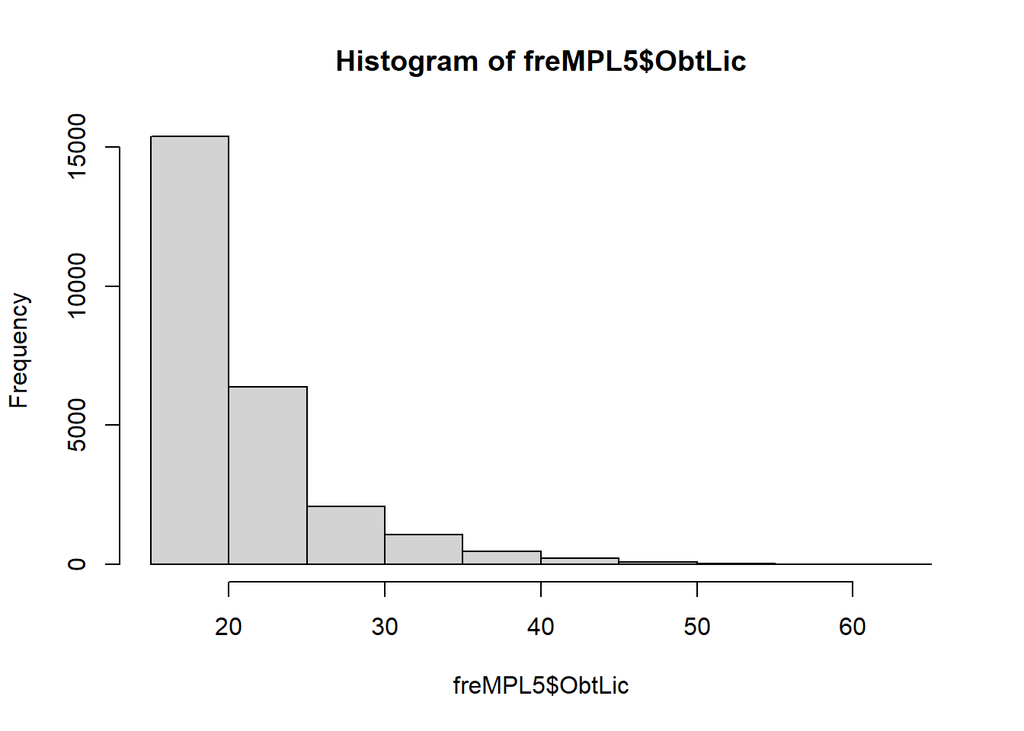

```r
hist(freMPL5$ObtLic)
```

```r
summary(freMPL5$ObtLic[freMPL5$ClaimInd == 0])
```

```
##    Min. 1st Qu.  Median    Mean 3rd Qu.    Max.
##   16.00   19.00   20.00   21.75   23.00   63.00
```

```r
summary(freMPL5$ObtLic[freMPL5$ClaimInd == 1])
```

```
##    Min. 1st Qu.  Median    Mean 3rd Qu.    Max.
##   17.00   18.00   20.00   21.56   22.00   62.00
```

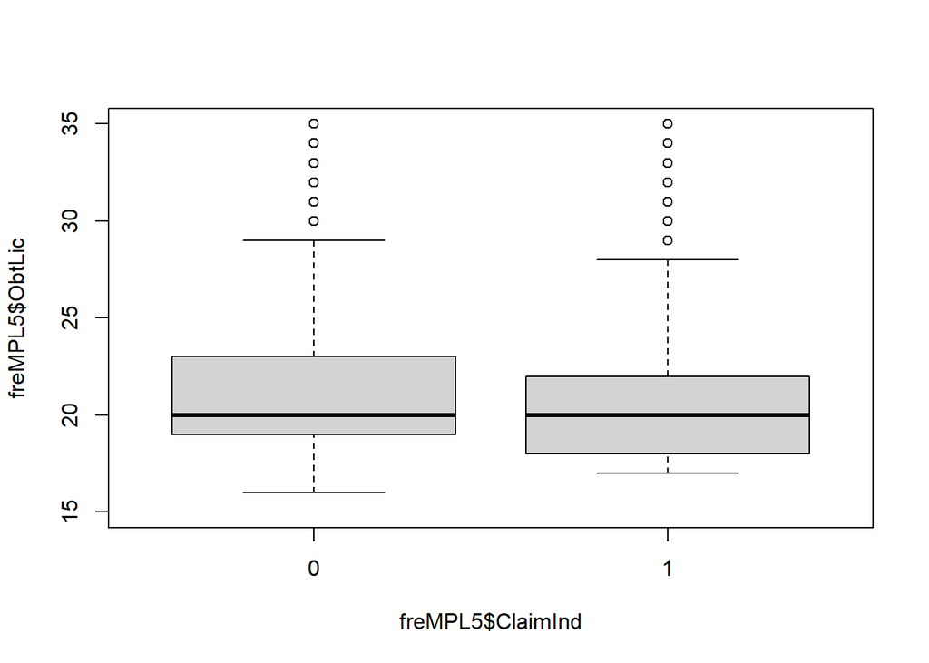

```r
boxplot(freMPL5$ObtLic ~ freMPL5$ClaimInd, , ylim=c(15,35))
```

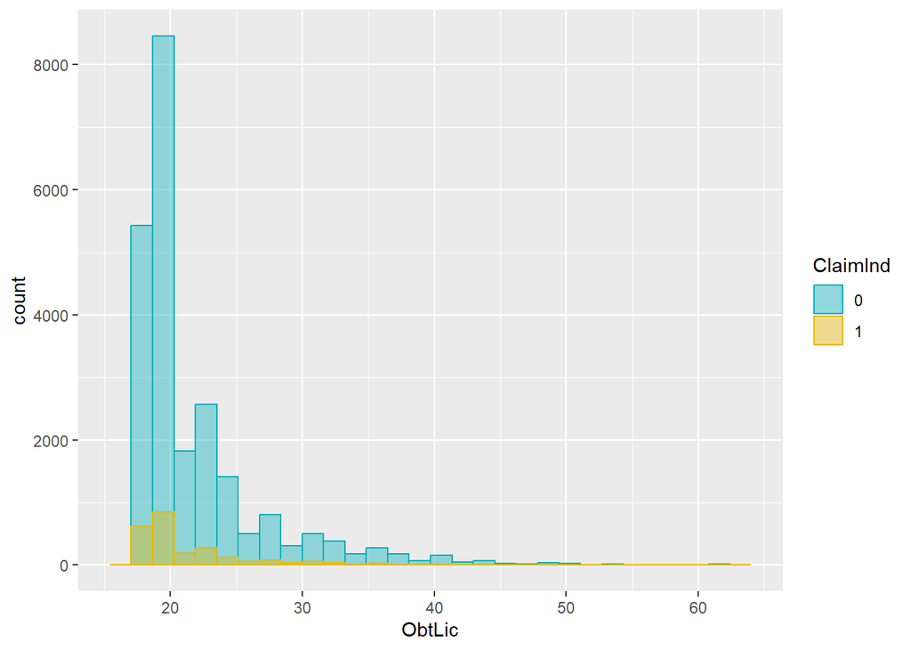

```r
ggplot(freMPL5, aes(x = ObtLic)) +
  geom_histogram(aes(color = ClaimInd, fill = ClaimInd),
                position = "identity", bins = 30, alpha = 0.4) +
  scale_color_manual(values = c("#00AFBB", "#E7B800")) +
  scale_fill_manual(values = c("#00AFBB", "#E7B800"))
```

Il peut y avoir un éventuel impact sur les quartiles. Sinon, la médiane reste sensiblement la même.